# Stationarity & introductory functions

10 Jan 2019

## Topics for today

### Characteristics of time series (ts)

- Expectation, mean & variance
- Covariance & correlation
- Stationarity
- Autocovariance & autocorrelation
- Correlograms
- White noise
- Random walks
- Backshift & difference operators

## Expectation & the mean

The expectation (\(E\)) of a variable is its mean value in the population

\(\text{E}(x) \equiv\) mean of \(x = \mu\)

Can estimate \(\mu\) from a sample as

\[ m = \frac{\sum_{i=1}^N{x_i}}{N} \]

## Variance

\(\text{E}([x - \mu]^2) \equiv\) expected deviations of \(x\) about \(\mu\)

\(\text{E}([x - \mu]^2) \equiv\) variance of \(x = \sigma^2\)

Can estimate \(\sigma^2\) from a sample as

\[ s^2 = \frac{1}{N-1}\sum_{i=1}^N{(x_i - m)^2} \]

## Covariance

If we have two variables, \(x\) and \(y\), we can generalize variance

\[ \sigma^2 = \text{E}([x_i - \mu][x_i - \mu]) \]

into *covariance*

\[ \gamma_{x,y} = \text{E}([x_i - \mu_x][y_i - \mu_y]) \]

## Covariance

If we have two variables, \(x\) and \(y\), we can generalize variance

\[ \sigma^2 = \text{E}([x_i - \mu][x_i - \mu]) \]

into *covariance*

\[ \gamma_{x,y} = \text{E}([x_i - \mu_x][y_i - \mu_y]) \]

Can estimate \(\gamma_{x,y}\) from a sample as

\[ \text{Cov}(x,y) = \frac{1}{N-1}\sum_{i=1}^N{(x_i - m_x)(y_i - m_y)} \]

## Graphical example of covariance

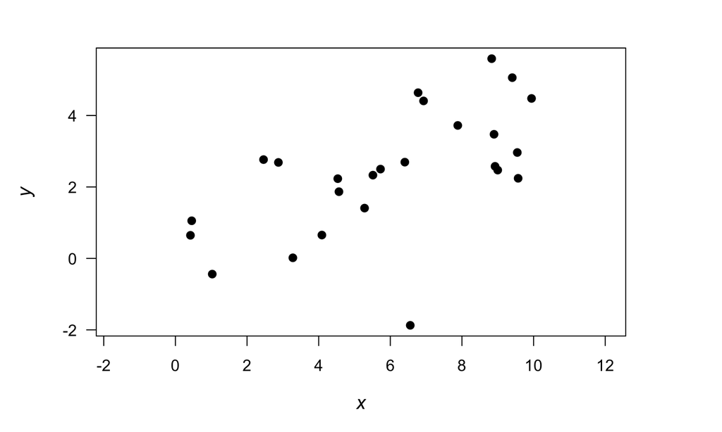

## Graphical example of covariance

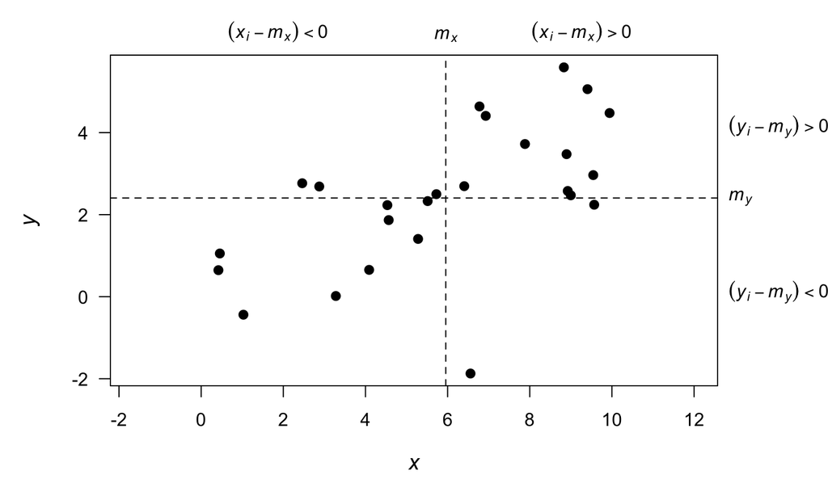

## Graphical example of covariance

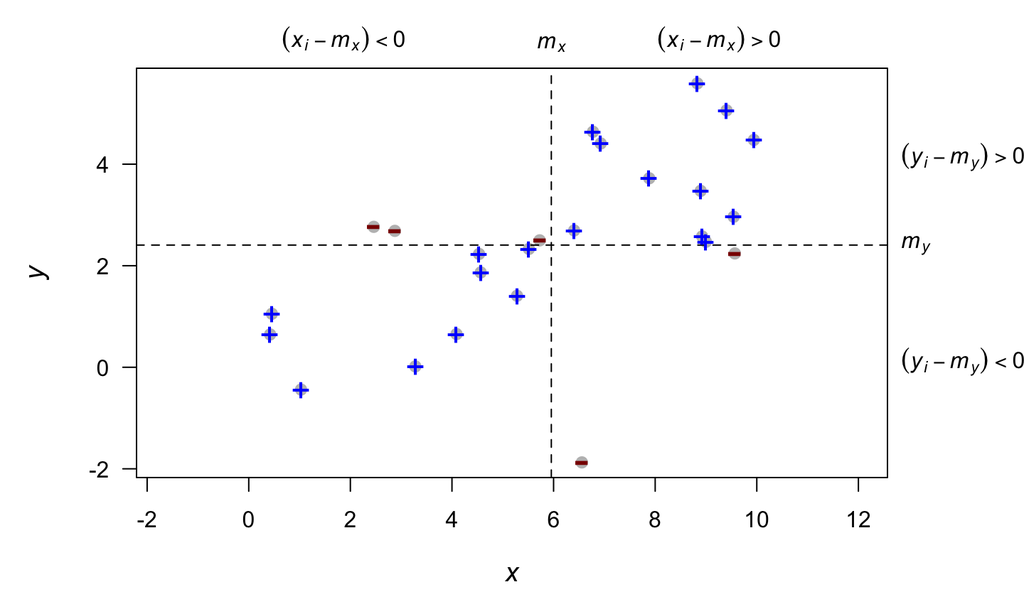

## Correlation

*Correlation* is a dimensionless measure of the linear association between 2 variables, \(x\) & \(y\)

It is simply the covariance standardized by the standard deviations

\[ \rho_{x,y} = \frac{\gamma_{x,y}}{\sigma_x \sigma_y} \]

\[ -1 < \rho_{x,y} < 1 \]

## Correlation

*Correlation* is a dimensionless measure of the linear association between 2 variables \(x\) & \(y\)

It is simply the covariance standardized by the standard deviations

\[ \rho_{x,y} = \frac{\gamma_{x,y}}{\sigma_x \sigma_y} \]

We can estimate \(\rho_{x,y}\) from a sample as

\[ \text{Cor}(x,y) = \frac{\text{Cov}(x,y)}{s_x s_y} \]

## Stationarity & the mean

Consider a single value, \(x_t\)

## Stationarity & the mean

Consider a single value, \(x_t\)

\(\text{E}(x_t)\) is taken across an ensemble of *all* possible time series

## Stationarity & the mean

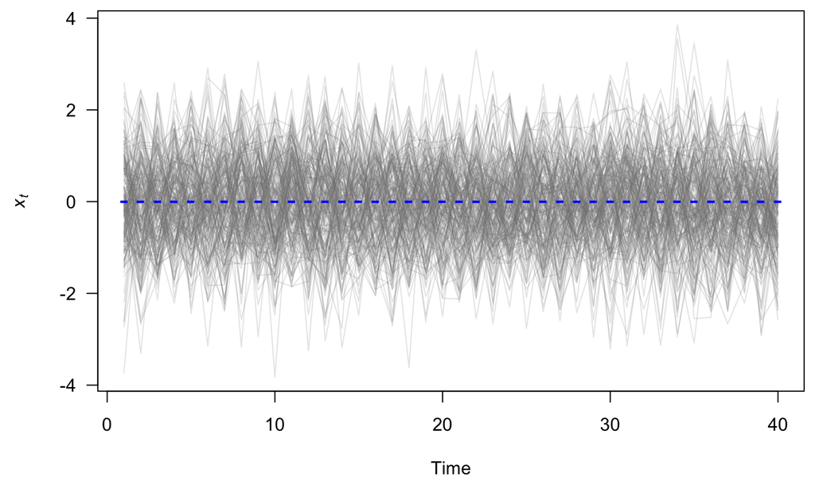

## Stationarity & the mean

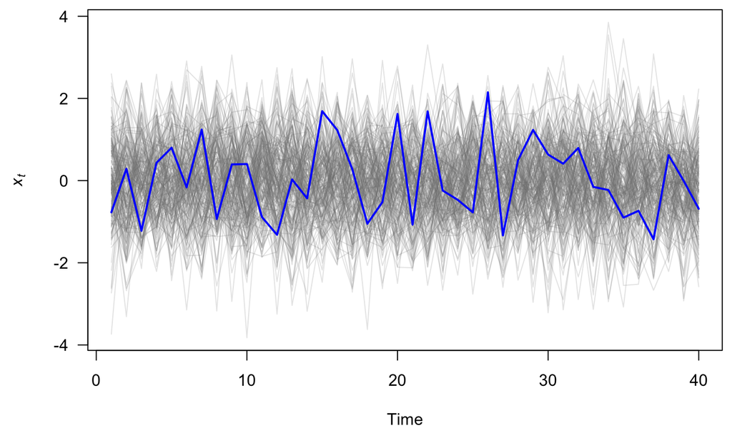

Our single realization is our estimate!

## Stationarity & the mean

If \(\text{E}(x_t)\) is constant across time, we say the time series is *stationary* in the mean

## Stationarity of time series

*Stationarity* is a convenient assumption that allows us to describe the statistical properties of a time series.

In general, a time series is said to be stationary if there is

1. no systematic change in the mean or variance
2. no systematic trend
3. no periodic variations or seasonality

## Identifying stationarity

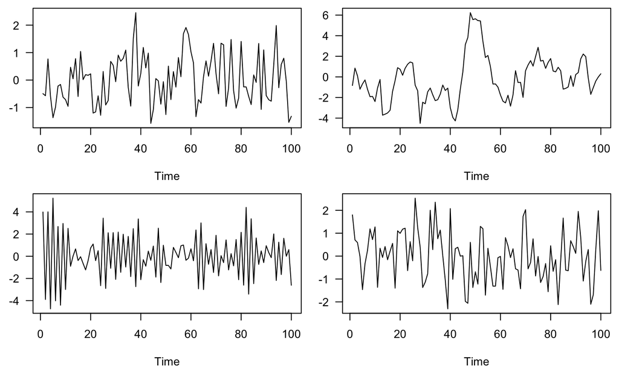

## Identifying stationarity

Our eyes are really bad at identifying stationarity, so we will learn some tools to help us

## Autocovariance function (ACVF)

For stationary ts, we define the *autocovariance function* (\(\gamma_k\)) as

\[ \gamma_k = \text{E}([x_t - \mu][x_{t+k} - \mu]) \]

which means that

\[ \gamma_0 = \text{E}([x_t - \mu][x_{t} - \mu]) = \sigma^2 \]

## Autocovariance function (ACVF)

For stationary ts, we define the *autocovariance function* (\(\gamma_k\)) as

\[ \gamma_k = \text{E}([x_t - \mu][x_{t+k} - \mu]) \]

"Smooth" series have large ACVF for large \(k\)

"Choppy" series have ACVF near 0 for small \(k\)

## Autocovariance function (ACVF)

For stationary ts, we define the *autocovariance function* (\(\gamma_k\)) as

\[ \gamma_k = \text{E}([x_t - \mu][x_{t+k} - \mu]) \]

We can estimate \(\gamma_k\) from a sample as

\[ c_k = \frac{1}{N}\sum_{t=1}^{N-k}{(x_t - m)(x_{t+k} - m)} \]

## Autocorrelation function (ACF)

The *autocorrelation function* (ACF) is simply the ACVF normalized by the variance

\[ \rho_k = \frac{\gamma_k}{\sigma^2} = \frac{\gamma_k}{\gamma_0} \]

The ACF measures the correlation of a time series against a time-shifted version of itself

## Autocorrelation function (ACF)

The *autocorrelation function* (ACF) is simply the ACVF normalized by the variance

\[ \rho_k = \frac{\gamma_k}{\sigma^2} = \frac{\gamma_k}{\gamma_0} \]

The ACF measures the correlation of a time series against a time-shifted version of itself

Can estimate ACF from a sample as

\[ r_k = \frac{c_k}{c_0} \]

## Properties of the ACF

The ACF has several important properties:

- \(-1 \leq r_k \leq 1\)
- \(r_k = r_{-k}\) (it’s an “even function”)
- \(r_k\) of periodic function is itself periodic
- \(r_k\) for the sum of 2 independent variables is the sum of \(r_k\) for each of them